# Taller Evaluable 1, FIFA 2022-23

[figure not shown]

# 1 Taller evaluable datos FIFA 2023

Cada pregunta vale 1 punto menos las dos últimas que valen 1.5 puntos. Se puntúa la presentación, la claridad y que los dibujos están completos. Este taller está pensado para resolver con R-base pero podéis utilizar tidyverse u otros paquetes de R.

En la web de kaggle [FIFA23 OFFICIAL DATASET](https://www.kaggle.com/datasets/bryanb/fifa-player-stats-database). Contiene todos los data sets de de datos básicos de FIFA17 to FIFA23 del videojuego.

Las siguientes preguntas son relativas al data set `players_23.csv`, que se adjunta con la práctica.

Hay que contestar con código R explicar adecuadamente cada salida. Subid a la activad el Rmd y el html.

Rellenad estos datos:

**PONED NOMBRE DEL GRUPO**

- Florit Ensenyat, Jordi
- Ferrer Fernández, Marc
- Girón Rodríguez, Pau
- Fornés Reynés, Josep Gabriel

## 1.1 Carga de datos

Tenéis que carga los datos con el código que se ve a continuación. Visualizar y explorara el data set y averiguar de qué tipo son cada una de las variables y en qué tipo de fichero están guardadas. El código carga los datos en un data frame llamado `datos` con la función `read.csv`. Debéis entender clases y tipos de datos de cada de cada columna de datos. El parámetro `encoding` es necesario para cargar debidamente los acentos y caracteres especiales. Lo que obtenemos es un data frame de 18539 observaciones (filas) y 90 variables (columnas).

Cargaremos todas las variables de texto como factor con el parámetro `stringsAsFactors = TRUE`

```r
datos = read.csv("players_fifa23.csv",
  encoding="UTF-8",stringsAsFactors = TRUE)# cambia tu path
#str(datos)
#names(datos)
```

Las variables de la 1 (`NationalTeam`) a la 31(`NationalPosition`) son variables de perfil del jugador: su nombre, su equipo su sueldo su número de camiseta… El resto de variables de la 34 (`pace`) a la 90 (`rb`) son variables numéricas enteras con valores de 0 a 100 que parametrizan cómo es el jugador el el juego FIFA player 2023.

## 1.2 Pregunta 1

Las selecciones europeas que han ganado un mundial son

```r
eur=c("England","France","Germany","Italy","Portugal","Spain")
eur
```

```
## [1] "England"  "France"   "Germany"  "Italy"    "Portugal" "Spain"
```

Generar un data frame con el nombre `fifa23_eur` con los jugadores de estas selecciones.

### 1.2.1 Solución 1

Estos son los jugadores de las selecciones europeas que han ganado un mundial. Usamos la funcion droplevels para quitar los niveles no usados.

```r
fifa23_eur = datos[datos$NationalTeam %in% eur,]
fifa23_eur$NationalTeam = droplevels(fifa23_eur$NationalTeam)
unique(fifa23_eur$Name)
```

```
##   [1] K. Benzema        K. Mbappé         M. Neuer          Cristiano Ronaldo
##   [5] H. Kane           J. Kimmich        N. Kanté          Rúben Dias
##   [9] G. Donnarumma     Bernardo Silva    João Cancelo      M. ter Stegen
##  [13] A. Rüdiger        Rodri             H. Lloris         T. Müller
##  [17] De Gea            M. Verratti       M. Maignan        L. Goretzka
##  [21] C. Immobile       R. Sterling       K. Trapp          Bruno Fernandes
##  [25] A. Laporte        K. Coman          N. Barella        C. Nkunku
##  [29] N. Süle           S. Gnabry         İ. Gündoğan       K. Walker
##  [33] Jordi Alba        Sergio Busquets   P. Pogba          Jorginho
##  [37] Gerard Moreno     Pedri             P. Foden          T. Hernández
##  [41] Diogo Jota        M. Reus           L. Hernández      Sergio Ramos
##  [45] D. Berardi        J. Grealish       Carvajal          R. Varane
##  [49] W. Ben Yedder     L. Insigne        K. Trippier       L. Bonucci
##  [53] J. Bellingham     F. Chiesa         Rafael Leão       J. Koundé
##  [57] L. Sané           R. James          A. Bastoni        K. Havertz
```

[output cut: 21 more lines]

## 1.3 Pregunta 2

Calcular la media y la desviación típica del valor de cada selección nacional cada equipo del data frame `fifa23_eur`.

Calcular la media y la desviación típica EN MILES de euros del valor de cada jugador `ValueEUR` de cada selección nacional del frame `fifa23_eur` por posición en el campo delantera media y defensa.

### 1.3.1 Solucion 2

Tabla con la media y la desviación típica:

```r
tabla=as.data.frame(aggregate(ValueEUR~NationalTeam, data=fifa23_eur,
                      FUN=function(x){c(media=mean(x,na.rm = TRUE), desv.tip=sd(x,na.rm = TRUE))}))
tabla
```

```
##   NationalTeam ValueEUR.media ValueEUR.desv.tip
## 1      England       47695652          25416861
## 2       France       52739130          37953581
## 3      Germany       47891304          24953573
## 4        Italy       39356522          27155626
## 5     Portugal       43213043          29830892
## 6        Spain       41956522          24335679
```

En la siguiente tabla vemos la media y la desviacion tipica en base a cada jugador de las selecciones nacionales:

```r
tabla2=as.data.frame(aggregate(ValueEUR~NationalTeam+NationalPosition, data=fifa23_eur,
                      FUN=function(x){c(media=mean(x/1000,na.rm = TRUE),
                                        min=min((x/1000),na.rm=TRUE),
                                        max=max((x/1000),na.rm=TRUE),
                                        desv.tip=sd((x/1000),na.rm = TRUE))}))
tabla2
```

```
##    NationalTeam NationalPosition ValueEUR.media ValueEUR.min ValueEUR.max
## 1       England              CAM      57500.000    57500.000    57500.000
## 2        France              CAM      30500.000    30500.000    30500.000
## 3       Germany              CAM      63000.000    63000.000    63000.000
## 4       England               CB      29250.000    24000.000    34500.000
## 5        France               CB      41666.667    39000.000    46000.000
## 6       Germany               CB      66250.000    59000.000    73500.000
## 7         Italy               CB      35750.000    11000.000    60500.000
## 8      Portugal               CB      56050.000     4600.000   107500.000
## 9         Spain               CB      42250.000    20000.000    64500.000
## 10       France              CDM      62250.000    52500.000    72000.000
## 11      Germany              CDM      74750.000    44000.000   105500.000
## 12     Portugal              CDM      47500.000    47500.000    47500.000
## 13        Spain              CDM      26500.000    26500.000    26500.000
## 14      England               CM      42000.000    32000.000    52000.000
```

[output cut: 101 more lines]

## 1.4 Pregunta 3

Discretiza la variable `ValueEUR` de `fifa23_eur` en los 4 niveles siguientes: “Cuartil_1”, “Cuartil_2”, “Cuartil_3” y “Cuartil_4”, según los cortes por la función `quantile`para 0.25,0.5 y 0.75. La variable resultante Value_Level tiene que ser un factor ordenado en orden creciente de valor.

### 1.4.1 Solución 3

```r
quantile(fifa23_eur$ValueEUR,probs = c(0.25,0.5,0.75))
```

```
##      25%      50%      75%
## 26625000 39500000 60125000
```

```r
valor4=ordered(cut(fifa23_eur$ValueEUR,
                   breaks=c(0,quantile(fifa23_eur$ValueEUR,probs = c(0.25,0.5,0.75)),Inf)))


table(valor4)
```

```
## valor4
##        (0,2.66e+07] (2.66e+07,3.95e+07] (3.95e+07,6.01e+07]      (6.01e+07,Inf]
##                  35                  34                  34                  35
```

```r
Value_Level <- factor(valor4,labels=c("Cuartil_1", "Cuartil_2", "Cuartil_3" , "Cuartil_4"))
table(Value_Level)
```

```
## Value_Level
## Cuartil_1 Cuartil_2 Cuartil_3 Cuartil_4
##        35        34        34        35
```

## 1.5 Pregunta 4

¿Qué selección tiene a más jugadores en el intervalo de Valor máximo calculado en el ejercicio anterior?

Estudiad la función `droplevels` para quitar los niveles de las selecciones que no aparecen.

### 1.5.1 Solución 4

Podemos ver que la selección con los jugadores de más valor es Francia.

```r
table(valor4,droplevels(fifa23_eur$NationalTeam))
```

```
##
## valor4                England France Germany Italy Portugal Spain
##   (0,2.66e+07]              4      5       5     8        6     7
##   (2.66e+07,3.95e+07]       8      5       5     5        6     5
##   (3.95e+07,6.01e+07]       5      5       7     5        4     8
##   (6.01e+07,Inf]            6      8       6     5        7     3
```

## 1.6 Pregunta 5

¿Respecto al tiro cuántos zurdos, diestros y ambidiestros (3) (buscad qué variable es e interpretar su valor de 1 a 5) hay entre todos los jugadores de `fifa23_eur`? Construir una variable llamada `foot` que tenga por niveles “left”, “right”,“ambidextrous” ¿Qué selección tiene mayor cantidad de zurdos (decidid que es zurdo diestro y ambidiestro)?

### 1.6.1 Solución 5

Consideramos que la variable `WeakFoot` de los jugadores nos indica segun el nivel de dicha variable su pierna de tiro.

```r
table(fifa23_eur$WeakFoot)
```

```
##
##  1  2  3  4  5
##  1 12 63 56  6
```

Creamos la variable `foot` que contenga esos niveles. Determinamos que entre 1-2 el jugador usa la pierna izquierda “left”, si el valor es 3 el jugador es ambidiestro “ambidextrous” y finalment entre 4-5 la pierna derecha “right” y en total hay los siguientes jugadores:

```r
fifa23_eur$foot = factor(ifelse(fifa23_eur$WeakFoot <= 2, "left", ifelse(fifa23_eur$WeakFoot == 3, "ambidextrous", "right")))
table(fifa23_eur$foot)
```

```
##
## ambidextrous         left        right
##           63           13           62
```

```r
table(fifa23_eur$NationalTeam,fifa23_eur$foot)
```

```
##
##            ambidextrous left right
##   England            15    2     6
##   France             14    3     6
##   Germany             5    2    16
##   Italy               9    2    12
##   Portugal            8    4    11
##   Spain              12    0    11
```

## 1.7 Pregunta 6

Calcular la la tabla de contingencia (frecuencias absolutas) por posición `NationalPosition` contra `foot`. contingencia con las variable `foot`. Calcular la tabla global de proporciones de `NationalPosition` y `foot`. Calcular la tabla de proporciones marginales de `foot` por (condicionada a) `NationalPosition`.

### 1.7.1 Solución 6

Tala de contingencia que muestra el numero de jugadores con X pierna dominante por posición.

```r
tabla1 = table(fifa23_eur$NationalPosition,fifa23_eur$foot)
tabla1
```

```
##
##       ambidextrous left right
##                  0    0     0
##   CAM            1    0     2
##   CB             8    1     4
##   CDM            2    0     4
##   CM             6    0     3
##   GK             2    2     2
##   LB             2    2     1
##   LF             0    0     0
##   LM             0    2     0
##   LW             2    0     2
##   LWB            0    0     0
##   RB             2    1     2
##   RF             0    0     0
##   RM             1    0     1
##   RW             2    0     2
##   RWB            0    0     0
##   ST             0    0     7
##   SUB           35    5    32
```

En esta tabla vemos las probabilidades de su pierna dominante por posición.

```r
tabla2 = prop.table(tabla1)
tabla2
```

```
##
##       ambidextrous        left       right
##        0.000000000 0.000000000 0.000000000
##   CAM  0.007246377 0.000000000 0.014492754
##   CB   0.057971014 0.007246377 0.028985507
##   CDM  0.014492754 0.000000000 0.028985507
##   CM   0.043478261 0.000000000 0.021739130
##   GK   0.014492754 0.014492754 0.014492754
##   LB   0.014492754 0.014492754 0.007246377
##   LF   0.000000000 0.000000000 0.000000000
##   LM   0.000000000 0.014492754 0.000000000
##   LW   0.014492754 0.000000000 0.014492754
##   LWB  0.000000000 0.000000000 0.000000000
##   RB   0.014492754 0.007246377 0.014492754
##   RF   0.000000000 0.000000000 0.000000000
##   RM   0.007246377 0.000000000 0.007246377
##   RW   0.014492754 0.000000000 0.014492754
##   RWB  0.000000000 0.000000000 0.000000000
##   ST   0.000000000 0.000000000 0.050724638
##   SUB  0.253623188 0.036231884 0.231884058
```

```r
tabla3 = prop.table(table(fifa23_eur$foot,fifa23_eur$NationalPosition))
tabla3
```

```
##
##                                    CAM          CB         CDM          CM
##   ambidextrous 0.000000000 0.007246377 0.057971014 0.014492754 0.043478261
##   left         0.000000000 0.000000000 0.007246377 0.000000000 0.000000000
##   right        0.000000000 0.014492754 0.028985507 0.028985507 0.021739130
##
##                         GK          LB          LF          LM          LW
##   ambidextrous 0.014492754 0.014492754 0.000000000 0.000000000 0.014492754
##   left         0.014492754 0.014492754 0.000000000 0.014492754 0.000000000
##   right        0.014492754 0.007246377 0.000000000 0.000000000 0.014492754
##
##                        LWB          RB          RF          RM          RW
##   ambidextrous 0.000000000 0.014492754 0.000000000 0.007246377 0.014492754
##   left         0.000000000 0.007246377 0.000000000 0.000000000 0.000000000
##   right        0.000000000 0.014492754 0.000000000 0.007246377 0.014492754
##
##                        RWB          ST         SUB
##   ambidextrous 0.000000000 0.000000000 0.253623188
##   left         0.000000000 0.000000000 0.036231884
##   right        0.000000000 0.050724638 0.231884058
```

## 1.8 Pregunta 7

Calcular diagramas de barras adosados para la primera tabla del ejercicio anterior y un diagrama de mosaico de la segunda tabla. Poned una leyenda y nombre del gráfico y comentar los resultados con un pequeño párrafo.

### 1.8.1 Solución 7

El primer digrama representa el nº de jugadores con pierna dominante por posición. Vemos que la posición SUB destaca sobre las demás en las piernas AMBIDIESTRA y DIESTRA. El segundo es un mosaico que muestra el resultasdo de la tabla de proporciones anterior.

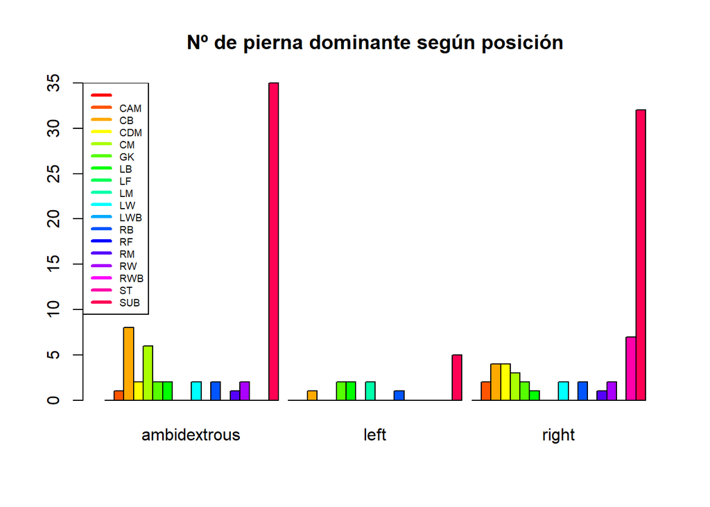

```r
barplot(tabla1,beside=TRUE,col=rainbow(18),main = "Nº de pierna dominante según posición" )
legend("topleft",col=rainbow(18),legend=c("","CAM","CB","CDM","CM","GK","LB","LF","LM","LW","LWB","RB","RF","RM","RW","RWB","ST","SUB"),lwd=3,bty="1",cex=0.6)
```

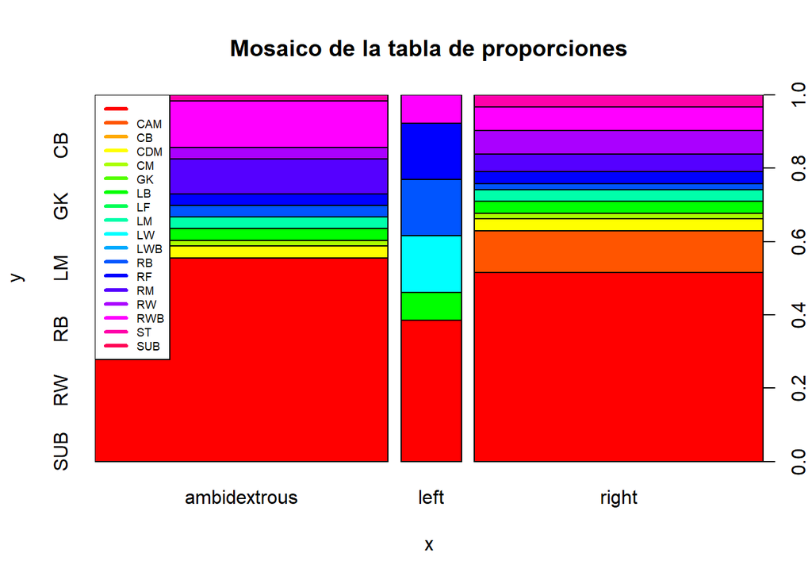

```r
plot(fifa23_eur$foot,fifa23_eur$NationalPosition,main = "Mosaico de la tabla de proporciones",col=rainbow(18))
legend("topleft",col=rainbow(18),legend=c("","CAM","CB","CDM","CM","GK","LB","LF","LM","LW","LWB","RB","RF","RM","RW","RWB","ST","SUB"),lwd=3,bty="1",cex=0.6)
```

## 1.9 Pregunta 8

Comparar la distribución del score `Overall` con un `boxplot` para las 6 selecciones. Decorar adecuadamente el resultado. Comentar los resultados.

### 1.9.1 Solución 8

Muestra la distribución de la media de los jugadores por selección. Vemos como por ejemplo, en Francia, la mayoría de sus jugadores rondan entre 82 y 86, pudiendo superar en pocos casos los 90 puntos.

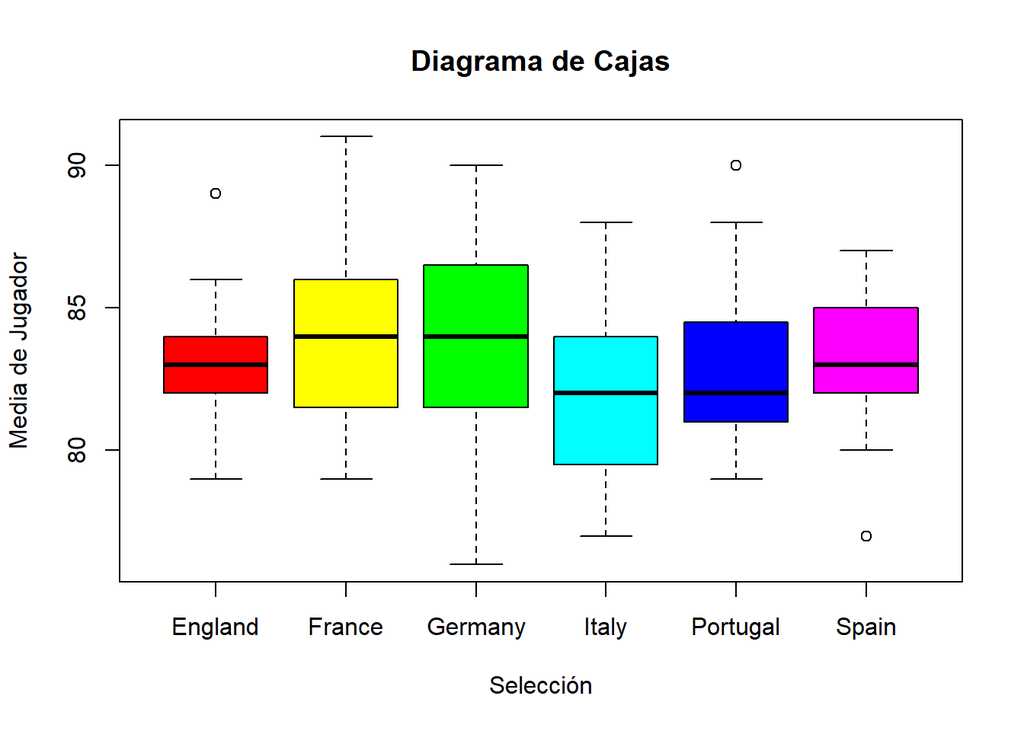

```r
boxplot(fifa23_eur$Overall~fifa23_eur$NationalTeam,main="Diagrama de Cajas",col=rainbow(6),xlab = "Selección",ylab = "Media de Jugador")
```

## 1.10 Pregunta 9

Generar un data frame `fifa23_ame` que contenga exclusivamente a las 6 selecciones de América que van al mundial 2022.

```r
ame=c("Argentina","Brazil","Canada","Mexico","Ecuador","United States" )
```

Generar un data frame `fifa23_ame`. Comparar la distribución del score `overall` para TODOS los jugadores de las 6 selecciones de europa y TODOS los jugadores de las seis selecciones de América. Dibujando un histograma con la función *kernel* en un solo gráfico. Comentar los resultados.

### 1.10.1 Solución 9

Creamos el data frame para los jugadores de las selecciones americanas.

```r
fifa23_ame=datos[datos$NationalTeam %in% ame,]
fifa23_ame$NationalTeam = droplevels(fifa23_ame$NationalTeam)
unique(fifa23_ame$NationalTeam)
```

```
## [1] Argentina     Canada        Brazil        Mexico        United States
## Levels: Argentina Brazil Canada Mexico United States
```

Comparamos la distribucion de las valoraciones `overall` de los jugadores.

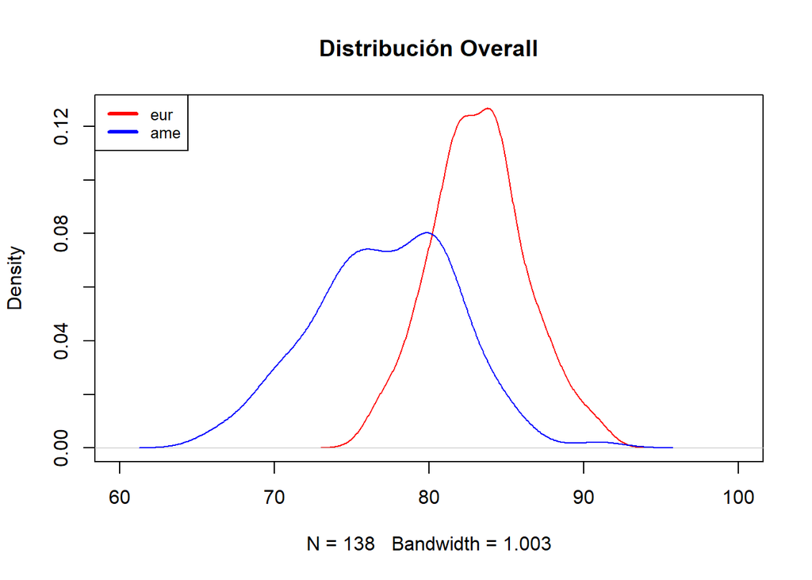

```r
plot(density(fifa23_eur$Overall),col="red",xlim=c(60,100),main = "Distribución Overall")
lines(density(fifa23_ame$Overall),col="blue")
legend("topleft",col=c("red","blue"), legend=c("eur","ame"),lwd=3,bty="l",cex=0.8)
```

Viendo la gráfica podemos determinar que la mayoria de jugadores europeos tienen una valoracion superior los jugadores de selecciones americanas.